# Introduction_to_PyTorch

**This tutorial is written by Habibur Rahman, Graduate Research Assistant, School of Materials Engineering, Purdue University, West Lafayette, IN Email: msehabibur@purdue.edu**

This tutorial provides a beginner-friendly introduction to Python, Tensors, PyTorch, and Neural Networks. We start with Python essentials and gradually explore Tensors and mathematical operations. Practical examples lead to the creation and training of a simple Neural Network using PyTorch. I later introduce DataLoader, Sequential, Skorch for efficient data handling. By the end, learners will have the skills to work with PyTorch and apply Deep Learning concepts.

```python
from google.colab import drive
drive.mount('/content/drive')
```

**DataType in Python**

```python
# Declaring variables
integer_var = 42  # An integer
float_var = 3.14  # A floating-point number
string_var = "Hello, Python!"  # A string
list_var = [1, 2, 3]  # A list
dictionary_var = {"name": "Alice", "age": 30}  # A dictionary
boolean_var = True  # A Boolean value
none_var = None  # A variable with no value

# Checking data types
print(type(integer_var))  # <class 'int'>
print(type(float_var))  # <class 'float'>
print(type(string_var))  # <class 'str'>
print(type(list_var))  # <class 'list'>
print(type(dictionary_var))  # <class 'dict'>
print(type(boolean_var))  # <class 'bool'>
print(type(none_var))  # <class 'NoneType'>
```

```
<class 'int'>
<class 'float'>
<class 'str'>
<class 'list'>
<class 'dict'>
<class 'bool'>
<class 'NoneType'>
```

**Tuple in Python**

```python
#In Python, a tuple is a collection data type that is used to store an ordered sequence of elements. Tuples are similar to lists, but they have a few key differences:
#Immutable: Tuples are immutable, which means their elements cannot be changed after creation. Once you define a tuple, you can't add, remove, or modify its elements. This immutability is in contrast to lists, which are mutable.
#Ordered: Like lists, tuples maintain the order of their elements. This means that the elements are stored in a specific sequence, and you can access them using indexing.
#Heterogeneous: Tuples can contain elements of different data types, such as integers, strings, floats, or even other tuples. This allows you to create more complex data structures.
#Tuples are often used for situations where you want to group multiple pieces of data together, and you want to ensure that the data remains constant and in a specific order.
#Here's how you can create a tuple in Python:
# Creating a tuple
#Tuples are particularly useful when you want to ensure that the data remains constant and ordered, which can be beneficial in various programming scenarios, such as representing coordinates, dates, or records.
my_tuple = (1, "apple", 3.14)

# Accessing elements by index
print(my_tuple[0])  # Output: 1
print(my_tuple[1])  # Output: "apple"
print(my_tuple[2])  # Output: 3.14
```

```
1
apple
3.14
```

**Class, method, function and object in Python**

```python
class Person:
    def __init__(self, name, age):
        self.name = name
        self.age = age

    def introduce(self):
        return f"My name is {self.name}, and I am {self.age} years old."

# Creating objects (instances) of the Person class
person1 = Person("Alice", 30)
person2 = Person("Bob", 25)

# Accessing object attributes and calling methods
print(person1.introduce())  # Output: "My name is Alice, and I am 30 years old."
print(person2.introduce())  # Output: "My name is Bob, and I am 25 years old."

#Class:A class is a blueprint for creating objects. It defines the structure and behavior of objects of that class. Here's an example of defining a simple Person class:
#Method:A method is a function that is defined within a class and operates on its instance (object) or class itself. In the example above, introduce is a method of the Person class.
#Object:An object is an instance of a class, created based on the class blueprint. In the code snippet above, person1 and person2 are objects of the Person class.
#Function:A function is a block of reusable code that performs a specific task. Functions can be defined inside or outside of a class. Here's an example of a standalone function:
def add(a, b):
    return a + b

result = add(5, 3)
print(result)  # Output: 8


#In this example, add is a standalone function that takes two arguments and returns their sum.
#To summarize, a class defines a blueprint for objects, a method is a function associated with a class, an object is an instance of a class, and a function is a standalone block of code that can be reused.
#These concepts are fundamental in object-oriented programming and general programming in Python.
```

```
My name is Alice, and I am 30 years old.
My name is Bob, and I am 25 years old.
8
```

**If statment in Python**

```python
temperature = 25

if temperature < 0:
    print("It's freezing outside.")
elif temperature >= 0 and temperature < 20:
    print("It's chilly.")
elif temperature >= 20 and temperature < 30:
    print("It's a pleasant day.")
else:
    print("It's hot outside.")
```

```
It's a pleasant day.
```

**Loop in Python**

```python
# Example 1: Iterating over a list
fruits = ["apple", "banana", "cherry"]
for fruit in fruits:
    print(fruit)

# Example 2: Iterating over a string
word = "Python"
for letter in word:
    print(letter)

# Example 3: Iterating over a range of numbers
for i in range(1, 6):  # Loop from 1 to 5 (inclusive)
    print(i)

# Example 4: Iterating over a dictionary's keys and values
person = {"name": "Alice", "age": 30, "city": "New York"}
for key, value in person.items():
    print(f"{key}: {value}")

# Example 5: Iterating with a step in a range
for i in range(0, 10, 2):  # Loop through even numbers from 0 to 8
    print(i)

# Example 6: Looping through a list of tuples
coordinates = [(1, 2), (3, 4), (5, 6)]
for x, y in coordinates:
    print(f"X: {x}, Y: {y}")

# Example 7: Iterating over a list and skipping certain elements
numbers = [1, 2, 3, 4, 5]
for number in numbers:
    if number % 2 == 0:
        continue  # Skip even numbers
    print(number)

# Example 8: Using the enumerate function to get both the index and value
fruits = ["apple", "banana", "cherry"]
for index, fruit in enumerate(fruits):
    print(f"Index {index}: {fruit}")

# Example 9: Iterating in reverse
numbers = [1, 2, 3, 4, 5]
for number in reversed(numbers):
    print(number)
```

```
apple
banana
cherry
P
y
t
h
o
n
1
2
3
4
5
name: Alice
age: 30
city: New York
0
2
4
6
8
X: 1, Y: 2
X: 3, Y: 4
X: 5, Y: 6
1
3
5
Index 0: apple
Index 1: banana
Index 2: cherry
5
4
3
2
1
```

**Adding all together**

```python
# Python Basics Example

# Variable declaration
name = "Alice"
age = 30
is_student = False

# Conditional statement
if is_student:
    print("Hello, student!")
else:
    print("Hello, non-student!")

# Loop (for loop)
for i in range(1, 6):
    print(f"Count: {i}")

# Loop (while loop)
count = 1
while count <= 5:
    print(f"Count: {count}")
    count += 1

# User input
user_name = input("Enter your name: ")
print(f"Hello, {user_name}!")

# Functions
def greet(name):
    return f"Hello, {name}!"

print(greet("Bob"))

# Lists
fruits = ["apple", "banana", "cherry"]
print("Fruits:", fruits)

# Dictionaries
person = {"name": "Alice", "age": 30, "is_student": False}
print("Person:", person)
```

```
Hello, non-student!
Count: 1
Count: 2
Count: 3
Count: 4
Count: 5
Count: 1
Count: 2
Count: 3
Count: 4
Count: 5
Enter your name: Roney
Hello, Roney!
Hello, Bob!
Fruits: ['apple', 'banana', 'cherry']
Person: {'name': 'Alice', 'age': 30, 'is_student': False}
```

**Scientific computing in Python**

```python
# NumPy is a fundamental library in the Python ecosystem for numerical and scientific computing.
# It provides a multitude of benefits and is widely used for a variety of tasks in data analysis, machine learning, scientific research, and more.
# Import the NumPy library
import numpy as np

# Creating NumPy arrays
arr1 = np.array([1, 2, 3, 4, 5])  # 1D array
arr2 = np.array([[1, 2, 3], [4, 5, 6]])  # 2D array (matrix)

# Basic operations with NumPy arrays
# Element-wise addition
result_add = arr1 + 10
# Element-wise multiplication
result_multiply = arr2 * 2

# Accessing elements in a NumPy array
element = arr2[1, 2]  # Access the element at row 1, column 2

# Shape of the array
shape = arr2.shape  # Returns a tuple (number of rows, number of columns)

# Getting the maximum and minimum values
max_value = arr1.max()
min_value = arr1.min()

# Compute the mean and sum of elements
mean_value = arr1.mean()
sum_value = arr1.sum()

# Printing the results
print("1D Array:")
print(arr1)
print("2D Array:")
print(arr2)
print("Element at (1, 2):", element)
print("Shape:", shape)
print("Max Value:", max_value)
print("Min Value:", min_value)
print("Mean Value:", mean_value)
print("Sum of Elements:", sum_value)
print("Adding 10 to arr1:", result_add)
print("Multiplying arr2 by 2:", result_multiply)

# Create an empty 3x3 array with a data type of float64
empty_array = np.empty((3, 3), dtype=np.float64)

print(empty_array)
```

```
1D Array:
[1 2 3 4 5]
2D Array:
[[1 2 3]
 [4 5 6]]
Element at (1, 2): 6
Shape: (2, 3)
Max Value: 5
Min Value: 1
Mean Value: 3.0
Sum of Elements: 15
Adding 10 to arr1: [11 12 13 14 15]
Multiplying arr2 by 2: [[ 2  4  6]
 [ 8 10 12]]
[[5.05648887e-310 0.00000000e+000 0.00000000e+000]
 [0.00000000e+000 0.00000000e+000 0.00000000e+000]
 [0.00000000e+000 0.00000000e+000 0.00000000e+000]]
```

**Data analysis in Python**

```python
import pandas as pd

# Create a sample DataFrame
data = {'Name': ['Alice', 'Bob', 'Charlie', 'David'],
        'Age': [25, 30, 35, 28],
        'City': ['New York', 'Los Angeles', 'Chicago', 'Houston']}

df = pd.DataFrame(data)

# Display the DataFrame
print("Original DataFrame:")
print(df)

# Selecting a single column
ages = df['Age']
print("\nAges:")
print(ages)

# Filtering rows based on a condition
young_people = df[df['Age'] < 30]
print("\nYoung People:")
print(young_people)

# Adding a new column
df['Salary'] = [50000, 60000, 75000, 48000]
print("\nDataFrame with Salary:")
print(df)

# Removing a column
df.drop('City', axis=1, inplace=True)
print("\nDataFrame without City:")
print(df)

# Descriptive statistics
summary_stats = df.describe()
print("\nSummary Statistics:")
print(summary_stats)
```

```
Original DataFrame:
      Name  Age         City
0    Alice   25     New York
1      Bob   30  Los Angeles
2  Charlie   35      Chicago
3    David   28      Houston

Ages:
0    25
1    30
2    35
3    28
Name: Age, dtype: int64

Young People:
    Name  Age      City
0  Alice   25  New York
3  David   28   Houston

DataFrame with Salary:
      Name  Age         City  Salary
0    Alice   25     New York   50000
1      Bob   30  Los Angeles   60000
2  Charlie   35      Chicago   75000
3    David   28      Houston   48000

DataFrame without City:
      Name  Age  Salary
0    Alice   25   50000
1      Bob   30   60000
2  Charlie   35   75000
3    David   28   48000

Summary Statistics:
             Age        Salary
count   4.000000      4.000000
mean   29.500000  58250.000000
std     4.203173  12338.962679
min    25.000000  48000.000000
25%    27.250000  49500.000000
50%    29.000000  55000.000000
75%    31.250000  63750.000000
max    35.000000  75000.000000
```

```
First few rows:
      Name  Age         City  Salary
0    Alice   25     New York   60000
1      Bob   30  Los Angeles   70000
2  Charlie   35      Chicago   75000
3    David   28      Houston   48000
4      Eve   27       Boston   55000

Last few rows:
      Name  Age         City  Salary
0    Alice   25     New York   60000
1      Bob   30  Los Angeles   70000
2  Charlie   35      Chicago   75000
3    David   28      Houston   48000
4      Eve   27       Boston   55000

DataFrame shape:
(5, 4)

Column names:
Index(['Name', 'Age', 'City', 'Salary'], dtype='object')

DataFrame information:
<class 'pandas.core.frame.DataFrame'>
RangeIndex: 5 entries, 0 to 4
Data columns (total 4 columns):
 #   Column  Non-Null Count  Dtype
---  ------  --------------  -----
 0   Name    5 non-null      object
 1   Age     5 non-null      int64
 2   City    5 non-null      object
 3   Salary  5 non-null      int64
dtypes: int64(2), object(2)
memory usage: 288.0+ bytes
None

Accessing a specific column:
0    25
1    30
2    35
```

[output cut: 45 more lines]

```
Creating a new column:
      Name  Age         City  Salary  Age_Squared
0    Alice   25     New York   60000          625
1      Bob   30  Los Angeles   70000          900
2  Charlie   35      Chicago   75000         1225
3    David   28      Houston   48000          784
4      Eve   27       Boston   55000          729

Sorting by Age:
      Name  Age         City  Salary  Age_Squared
0    Alice   25     New York   60000          625
4      Eve   27       Boston   55000          729
3    David   28      Houston   48000          784
1      Bob   30  Los Angeles   70000          900
2  Charlie   35      Chicago   75000         1225
```

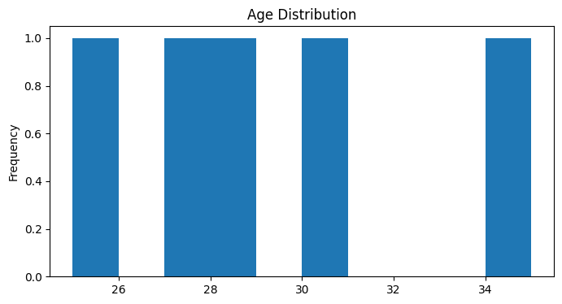

```
Data saved to 'sample_data.csv'

Data read from 'sample_data.csv':
      Name  Age         City  Salary  Age_Squared
0    Alice   25     New York   60000          625
1      Bob   30  Los Angeles   70000          900
2  Charlie   35      Chicago   75000         1225
3    David   28      Houston   48000          784
4      Eve   27       Boston   55000          729
```

```python
import pandas as pd

# Creating a sample DataFrame
data = {
    'Name': ['Alice', 'Bob', 'Charlie', 'David', 'Eve'],
    'Age': [25, 30, 35, 28, 27],
    'City': ['New York', 'Los Angeles', 'Chicago', 'Houston', 'Boston'],
    'Salary': [60000, 70000, 75000, 48000, 55000]
}

df = pd.DataFrame(data)

# Data Inspection
print("First few rows:")
print(df.head())

print("\nLast few rows:")
print(df.tail())

print("\nDataFrame shape:")
print(df.shape)

print("\nColumn names:")
print(df.columns)

print("\nDataFrame information:")
print(df.info())

# Data Selection and Indexing
print("\nAccessing a specific column:")
print(df['Age'])

print("\nSelecting multiple columns:")
print(df[['Name', 'City']])

print("\nAccessing a specific value:")
print(df.loc[2, 'Name'])

# Filtering and Querying
print("\nFiltering based on a condition:")
print(df[df['Age'] < 30])

print("\nQuerying data:")
print(df.query('Salary > 60000'))

# Data Aggregation and Summary Statistics
print("\nSummary Statistics:")
print(df.describe())

# Data Cleaning
print("\nDropping a column:")
df_cleaned = df.drop('Salary', axis=1)
print(df_cleaned)

# Data Transformation
print("\nCreating a new column:")
df['Age_Squared'] = df['Age'] ** 2
print(df)

# Sorting
print("\nSorting by Age:")
print(df.sort_values(by='Age'))

# Data Visualization
import matplotlib.pyplot as plt

plt.figure(figsize=(8, 4))
df['Age'].plot(kind='hist', title='Age Distribution')
plt.show()

# File I/O
df.to_csv('sample_data.csv', index=False)
print("Data saved to 'sample_data.csv'")

# Reading data from a CSV file
read_df = pd.read_csv('sample_data.csv')
print("\nData read from 'sample_data.csv':")
print(read_df)
```

**Introduction to Tensor**

In programming, tensors are typically used in libraries like PyTorch and TensorFlow to represent data that will be used in machine learning and deep learning models. These tensors can hold a wide range of data, including but not limited to:

- 1D Tensor: Time series data, sound waveforms, or any sequential data.
- 2D Tensor: Grayscale images (where each pixel is a number), text data (in the form of word embeddings), or any tabular data.
- 3D Tensor: Color images (often with dimensions for height, width, and color channels like RGB).
- 4D Tensor: A batch of color images, or video data (where time is an additional dimension).
- 5D Tensor: A batch of video data or any data that requires five dimensions to represent.

Tensors are particularly well-suited to represent data in machine learning because they can be efficiently processed using GPU acceleration, which is critical for training complex neural networks on large datasets. The operations on tensors (like addition, multiplication, etc.) are optimized to be fast and memory efficient, making them a cornerstone of numerical computing and deep learning.

**Perform mathematical operations with Tensors using the torch module in PyTorch**

```python
! pip install torch
```

```python
# importing the PyTorch library since the execution state was reset
import torch

# Let's define two tensors
tensor_a = torch.tensor([[1, 2], [3, 4]])
tensor_b = torch.tensor([[5, 6], [7, 8]])

# Addition
tensor_add = tensor_a + tensor_b

# Subtraction
tensor_sub = tensor_a - tensor_b

# Element-wise multiplication (Hadamard product)
tensor_mul = tensor_a * tensor_b

# Division
tensor_div = tensor_a / tensor_b

# Matrix multiplication
tensor_matmul = torch.matmul(tensor_a, tensor_b)

# Display the results
tensor_add, tensor_sub, tensor_mul, tensor_div, tensor_matmul
```

```
(tensor([[ 6,  8],
         [10, 12]]),
 tensor([[-4, -4],
         [-4, -4]]),
 tensor([[ 5, 12],
         [21, 32]]),
 tensor([[0.2000, 0.3333],
         [0.4286, 0.5000]]),
 tensor([[19, 22],
         [43, 50]]))
```

```python
# Re-importing the PyTorch library since the execution state was reset
import torch

# Let's go through some more tensor operations using PyTorch:

# Creating a tensor with random values
random_tensor = torch.rand((3, 3))

# Transposing a tensor
transposed_tensor = torch.transpose(random_tensor, 0, 1)

# Reshaping a tensor
reshaped_tensor = random_tensor.view(1,9)

# Calculating the mean of a tensor
mean_val = random_tensor.mean()

# Calculating the sum of a tensor
sum_val = random_tensor.sum()

# Concatenating two tensors along a new dimension
concatenated_tensor = torch.cat((random_tensor, random_tensor), dim=0)

# Computing the eigenvalues and eigenvectors of a square matrix
eigenvalues, eigenvectors = torch.linalg.eig(random_tensor)

# Examples of in-place operations (note the underscore at the end of the method name)
# Adding 1 to each element in-place
random_tensor.add_(1)

# Display the results
results = {
    "Random Tensor": random_tensor,
    "Transposed": transposed_tensor,
    "Reshaped": reshaped_tensor,
    "Mean Value": mean_val,
    "Sum Value": sum_val,
    "Concatenated": concatenated_tensor,
    "Eigenvalues": eigenvalues,
    "Eigenvectors": eigenvectors,
    "In-place Add": random_tensor
}

results
```

```
{'Random Tensor': tensor([[1.3326, 1.6908, 1.9897],
         [1.6358, 1.8065, 1.0785],
         [1.3820, 1.2168, 1.1411]]),
 'Transposed': tensor([[1.3326, 1.6358, 1.3820],
         [1.6908, 1.8065, 1.2168],
         [1.9897, 1.0785, 1.1411]]),
 'Reshaped': tensor([[1.3326, 1.6908, 1.9897, 1.6358, 1.8065, 1.0785, 1.3820, 1.2168, 1.1411]]),
 'Mean Value': tensor(0.4749),
 'Sum Value': tensor(4.2739),
 'Concatenated': tensor([[0.3326, 0.6908, 0.9897],
         [0.6358, 0.8065, 0.0785],
         [0.3820, 0.2168, 0.1411],
         [0.3326, 0.6908, 0.9897],
         [0.6358, 0.8065, 0.0785],
         [0.3820, 0.2168, 0.1411]]),
 'Eigenvalues': tensor([ 1.4735+0.j, -0.4569+0.j,  0.2636+0.j]),
 'Eigenvectors': tensor([[ 0.6718+0.j,  0.8325+0.j,  0.5455+0.j],
         [ 0.6760+0.j, -0.3948+0.j, -0.7046+0.j],
         [ 0.3026+0.j, -0.3886+0.j,  0.4538+0.j]]),
 'In-place Add': tensor([[1.3326, 1.6908, 1.9897],
         [1.6358, 1.8065, 1.0785],
         [1.3820, 1.2168, 1.1411]])}
```

Here are the results of the tensor operations performed using PyTorch:

**Create a PyTorch Neural Network model**

```python
import numpy as np
import pandas as pd
import torch
import torch.nn as nn
import torch.optim as optim
from sklearn.model_selection import train_test_split
from sklearn.preprocessing import LabelEncoder, StandardScaler
from sklearn.metrics import mean_squared_error
```

```python
# Set random seed for reproducibility
torch.manual_seed(42)
# Loading the dataset
data = pd.read_csv('/content/drive/MyDrive/DeepMSE/Medical_Insurance_Cost_Prediction_using_Machine_Learning/insurance.csv')
data.head(5)
```

|  | age | sex | bmi | children | smoker | region | charges |
| --- | --- | --- | --- | --- | --- | --- | --- |
| 0 | 19 | female | 27.900 | 0 | yes | southwest | 16884.92400 |
| 1 | 18 | male | 33.770 | 1 | no | southeast | 1725.55230 |
| 2 | 28 | male | 33.000 | 3 | no | southeast | 4449.46200 |
| 3 | 33 | male | 22.705 | 0 | no | northwest | 21984.47061 |
| 4 | 32 | male | 28.880 | 0 | no | northwest | 3866.85520 |

```python
# Encoding categorical columns

#The code takes the 'sex' column from the 'data' DataFrame and applies the fit_transform method of the encoder to it.
#fit_transform is a method that both fits the encoder to the unique values in the column and transforms those values into integer labels.
#After this line of code, the 'sex' column in the 'data' DataFrame will be replaced with the integer labels, with each unique category mapped to a unique integer value.
encoder = LabelEncoder()
data['sex'] = encoder.fit_transform(data['sex'])
data['smoker'] = encoder.fit_transform(data['smoker'])
data['region'] = encoder.fit_transform(data['region'])



# Splitting the dataset into training and testing sets
X = data.drop('charges', axis=1).values  # Features
y = data['charges'].values  # Target variable
X_train, X_test, y_train, y_test = train_test_split(X, y, test_size=0.3, random_state=42)

# Scaling the features
scaler = StandardScaler()
X_train_scaled = scaler.fit_transform(X_train)
X_test_scaled = scaler.transform(X_test)
```

```python
data.head(5)
```

|  | age | sex | bmi | children | smoker | region | charges |
| --- | --- | --- | --- | --- | --- | --- | --- |
| 0 | 19 | 0 | 27.900 | 0 | 1 | 3 | 16884.92400 |
| 1 | 18 | 1 | 33.770 | 1 | 0 | 2 | 1725.55230 |
| 2 | 28 | 1 | 33.000 | 3 | 0 | 2 | 4449.46200 |
| 3 | 33 | 1 | 22.705 | 0 | 0 | 1 | 21984.47061 |
| 4 | 32 | 1 | 28.880 | 0 | 0 | 1 | 3866.85520 |

```python
# Convert data to PyTorch tensors
X_train_tensor = torch.tensor(X_train_scaled, dtype=torch.float32)
y_train_tensor = torch.tensor(y_train, dtype=torch.float32).view(-1, 1)  # Reshape y to (N, 1)
X_test_tensor = torch.tensor(X_test_scaled, dtype=torch.float32)

#X_train_tensor = torch.tensor(X_train_scaled, dtype=torch.float32): This line creates a PyTorch tensor X_train_tensor from the NumPy array X_train_scaled.
#The dtype=torch.float32 argument specifies that the data type of the tensor should be 32-bit floating-point numbers.
#This is a common data type for training data. It's important to match the data type of your tensors with the expected data type of your model's input.
#y_train_tensor = torch.tensor(y_train, dtype=torch.float32).view(-1, 1): This line creates a PyTorch tensor y_train_tensor from the NumPy array y_train.
#The .view(-1, 1) part is used to reshape the tensor. In your machine learning task, it's common to have the target variable in the shape of (N, 1), where N is the number of samples.
#The .view(-1, 1) operation ensures that y_train_tensor has the correct shape, with one column (i.e., a single target value per sample).
#X_test_tensor = torch.tensor(X_test_scaled, dtype=torch.float32): This line is similar to the first line but for the testing data. It converts the NumPy array X_test_scaled to a PyTorch tensor with a data type of 32-bit floating-point numbers.
```

[output not shown]

```python
# Check if a GPU is available
device = torch.device("cuda" if torch.cuda.is_available() else "cpu")

# Send tensors to the GPU
X_train_tensor = X_train_tensor.to(device)
y_train_tensor = y_train_tensor.to(device)
X_test_tensor = X_test_tensor.to(device)
```

```python
class NeuralNetwork(nn.Module):
    def __init__(self, input_dim, hidden_dim, output_dim):
        super(NeuralNetwork, self).__init__()
        self.fc1 = nn.Linear(input_dim, hidden_dim)
        self.relu = nn.ReLU()
        self.fc2 = nn.Linear(hidden_dim, output_dim)

#class NeuralNetwork(nn.Module): This line defines a Python class named NeuralNetwork that inherits from nn.Module, which is a base class provided by PyTorch for defining neural network.
#In PyTorch, you typically create your custom neural network models by subclassing nn.Module.
#def __init__(self, input_dim, hidden_dim, output_dim): This is the constructor method for the NeuralNetwork class.
#It initializes the neural network model with the following parameters:
#input_dim: The dimensionality of the input features.
#hidden_dim: The number of units (neurons) in the hidden layer.
#output_dim: The dimensionality of the output (e.g., for regression, it's typically 1).
#super(NeuralNetwork, self).__init__(): This line calls the constructor of the parent class (nn.Module) to properly initialize the neural network.
#It's a standard practice to call the parent class's constructor first.
#self.fc1 = nn.Linear(input_dim, hidden_dim): This line defines the first fully connected (linear) layer in the neural network.
#It connects the input to the hidden layer. The nn.Linear module initializes the weights and biases for this layer.
#self.relu = nn.ReLU(): This line creates an instance of the Rectified Linear Unit (ReLU) activation function. The ReLU is applied element-wise to the output of the first linear layer, introducing non-linearity to the model.
#self.fc2 = nn.Linear(hidden_dim, output_dim): This line defines the second fully connected (linear) layer in the neural network, which connects the hidden layer to the output layer.

#In the given NeuralNetwork class, we have two hidden layers. These are represented by the self.fc1 and self.fc2 layers, both of which are instances of nn.Linear.Here's how the layers are structured:
#self.fc1 is the first hidden layer with input size input_dim and output size hidden_dim. It represents the first layer that processes the input data and extracts features.
#self.fc2 is the second hidden layer with input size hidden_dim and output size output_dim.
#It represents the second layer that further processes the features extracted by the first hidden layer and produces the final output of the neural network.
#So, we have two hidden layers in this neural network, one followed by the other. These layers are separated by a ReLU activation function (self.relu) applied after the first hidden layer.

    def forward(self, x):
        out = self.fc1(x)
        out = self.relu(out)
        out = self.fc2(out)
        return out
#def forward(self, x): This method defines the forward pass of the neural network. The forward method is called when you pass input data through the model.
#out = self.fc1(x): It computes the output of the first linear layer by applying it to the input x.
#out = self.relu(out): It applies the ReLU activation function to the output of the first linear layer.
#out = self.fc2(out): It computes the final output of the neural network by applying the second linear layer to the ReLU-activated output from the hidden layer.
#return out: The final output of the forward pass is returned, which represents the model's prediction.


#In the context of a neural network, nn.Linear is used to create the fully connected layers that connect the input data to subsequent layers
#allowing the network to learn and model complex relationships between features. The parameters (weights and biases) in this linear layer are learned during training
#to make the network perform a specific task, such as classification or regression.
#PyTorch nn module
#In addition to nn.Linear, PyTorch provides a variety of other functions and layers for building neural networks.
#Some of the commonly used layers and activation functions in PyTorch include:
#Convolutional Layers (nn.Conv2d, nn.ConvTranspose2d, etc.): These layers are used in convolutional neural networks (CNNs) for tasks like image processing.
#They perform convolution operations on the input data to capture spatial patterns.
#Recurrent Layers (nn.RNN, nn.LSTM, nn.GRU, etc.): These layers are used for sequential data processing, like time series or natural language processing.
#They can capture temporal dependencies in the data.
#Pooling Layers (nn.MaxPool2d, nn.AvgPool2d, etc.): These layers are often used in CNNs for downsampling and reducing the spatial dimensions of feature maps.
#Dropout (nn.Dropout): Dropout is a regularization technique that helps prevent overfitting by randomly setting a fraction of input units to zero during each forward pass.
#Batch Normalization (nn.BatchNorm2d, nn.BatchNorm1d): Batch normalization normalizes the activations of a layer, helping with training stability and faster convergence.
#Activation Functions (nn.ReLU, nn.Sigmoid, nn.Tanh, nn.LeakyReLU, etc.): Activation functions introduce non-linearity into the network, allowing it to model complex relationships.
#Softmax (nn.Softmax): Softmax is often used in the output layer for multi-class classification tasks. It converts raw scores (logits) into class probabilities.
#Loss Functions (nn.CrossEntropyLoss, nn.BCELoss, nn.MSELoss, etc.): These functions define the loss used for training the network, depending on the task.
#Embedding Layers (nn.Embedding): Embedding layers are used to convert discrete categorical data, such as word indices, into continuous vectors.
#Custom Layers and Architectures: PyTorch allows you to create custom layers and network architectures by subclassing nn.Module and defining your own forward pass.
```

```python
input_dim = X_train_tensor.shape[1]
hidden_dim = 100  # You can change this according to your choice
output_dim = 1

model = NeuralNetwork(input_dim, hidden_dim, output_dim)

# Define the loss function and optimizer
criterion = nn.MSELoss()

#This line creates an instance of the Mean Squared Error (MSE) loss function using nn.MSELoss. MSE is commonly used as a loss function for regression problems.
#It measures the average squared difference between the predicted values and the actual target values.
#The goal during training is to minimize this loss, which means making the model's predictions as close as possible to the actual target values.
criterion = nn.MSELoss()

optimizer = optim.Adam(model.parameters(), lr=0.001)  # You can adjust the learning rate

#This line initializes an Adam optimizer. The Adam optimizer is a popular optimization algorithm for training deep neural networks. It adjusts the model's parameters (weights and biases) during training to minimize the loss.
#model.parameters() provides all the parameters (weights and biases) of the model that need to be updated during training.
#lr=0.001 sets the learning rate, which is a hyperparameter that determines the step size at each iteration when the optimizer updates the model's parameters.
#A smaller learning rate makes the training process more stable but might require more iterations, while a larger learning rate can speed up convergence but risks overshooting the optimal solution.
```

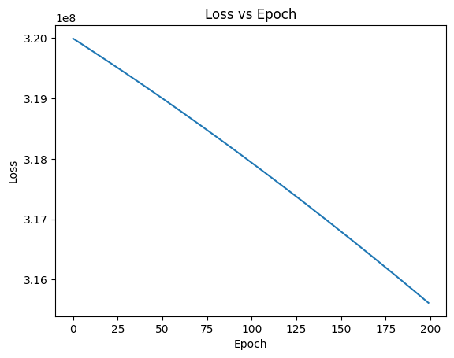

```python
import matplotlib.pyplot as plt  # You need to import the matplotlib library for plotting

# Training the model
num_epochs = 200  # You can adjust this
loss_values = []  # Create an empty list to store loss values

for epoch in range(num_epochs):
    # Forward pass
    outputs = model(X_train_tensor)
    loss = criterion(outputs, y_train_tensor)
    # Backward pass and optimization
    optimizer.zero_grad()
    loss.backward()
    optimizer.step()
    loss_values.append(loss.tolist())  # Append the loss value to the list
#num_epochs = 1000: This line sets the number of training epochs, which is the number of times the entire training dataset will be processed by the neural network during training.
#You can adjust this value based on your specific training requirements. Training for more epochs allows the model to learn better, up to a point, but it can also increase the risk of overfitting if not controlled properly.
#for epoch in range(num_epochs): This loop iterates over the specified number of training epochs, allowing the model to learn from the data over multiple passes.
#outputs = model(X_train_tensor): In this line, the input data X_train_tensor is passed through the neural network model (model) to obtain predictions (outputs).
#This is the forward pass, where the model takes input and produces predictions for each sample in the training dataset.
#loss = criterion(outputs, y_train_tensor): The loss is computed by comparing the model's predictions (outputs) to the actual target values (y_train_tensor).
#The criterion is typically a loss function, and in this case, it appears to be the Mean Squared Error (MSE) loss, which is commonly used for regression tasks.
#The loss quantifies how far the model's predictions are from the true values.
#optimizer.zero_grad(): This line zeroes out the gradients of the model's parameters.
#Gradients are accumulated during the backward pass, so you need to reset them before computing new gradients in each iteration.
#loss.backward(): In this line, the backward pass is performed. It computes gradients of the loss with respect to the model's parameters. These gradients are used to update the model's weights during optimization.
#PyTorch automatically computes these gradients for you using automatic differentiation.
#optimizer.step(): The optimizer updates the model's parameters using the computed gradients. This step effectively adjusts the model's weights to minimize the loss.
#The specific optimization algorithm used is typically defined when creating the optimizer (e.g., Adam, SGD).


# Plot the loss versus epoch
plt.plot(range(num_epochs), loss_values)
plt.xlabel('Epoch')
plt.ylabel('Loss')
plt.title('Loss vs Epoch')
plt.show()
```

```python
with torch.no_grad():
    y_pred = model(X_test_tensor)
    mse = mean_squared_error(y_test, y_pred.numpy())
    rmse = np.sqrt(mse)
    print('Root Mean Squared Error:', rmse)

#with torch.no_grad(): This is a context manager in PyTorch that temporarily disables gradient calculations for the code block within it.
#During evaluation, you don't need to compute gradients because you're not updating the model's parameters. Disabling gradient calculations can significantly reduce memory usage and speed up the evaluation process.
#y_pred = model(X_test_tensor): In this line, you pass the test data (X_test_tensor) through the trained neural network model (model) to obtain predictions (y_pred).
#These predictions represent the model's estimates for the target values in the test dataset.
#mse = mean_squared_error(y_test, y_pred.numpy()): This line computes the Mean Squared Error (MSE) between the true target values (y_test) and the predicted values (y_pred).
#The mean_squared_error function is from scikit-learn, and it calculates the MSE. MSE is a common metric used for regression tasks and measures the average squared difference between predicted and actual values.
#Lower MSE values indicate better model performance.
#rmse = np.sqrt(mse): After computing the MSE, this line calculates the Root Mean Squared Error (RMSE) by taking the square root of the MSE.
#RMSE is a more interpretable metric because it's in the same unit as the target variable. Lower RMSE values indicate better model performance.
#print('Root Mean Squared Error:', rmse): Finally, this line prints the RMSE, which provides a measure of how well the model performs on the test dataset. Lower RMSE indicates better predictive accuracy.
#You can also access the model's parameters if needed: This is a comment indicating that you can access the model's learned parameters (weights and biases) if you want to inspect or save them for future use.
#print('Model parameters:', model.state_dict()): This line is commented out, but if you were to uncomment it, it would print the model's parameters using the state_dict() method.
#The model's parameters are stored in a dictionary-like object, which can be useful for various purposes, such as saving or loading the trained model.
```

```
Root Mean Squared Error: 17353.284576266353
```

In PyTorch, nn.Sequential is a container that is used to define a sequential composition of Neural Network layers. It allows you to create a Neural Network model by specifying a sequence of layers in the order they should be applied during forward pass computations. It simplifies the process of defining and organizing Neural Network architectures, especially for feedforward Neural Networks.

```python
import numpy as np
import pandas as pd
import torch
import torch.nn as nn
import torch.optim as optim
from sklearn.model_selection import train_test_split
from sklearn.preprocessing import LabelEncoder, StandardScaler
from sklearn.metrics import mean_squared_error

# Set random seed for reproducibility
torch.manual_seed(42)

# Loading the dataset
data = pd.read_csv('/content/drive/MyDrive/DeepMSE/Medical_Insurance_Cost_Prediction_using_Machine_Learning/insurance.csv')

# Encoding categorical columns
encoder = LabelEncoder()
data['sex'] = encoder.fit_transform(data['sex'])
data['smoker'] = encoder.fit_transform(data['smoker'])
data['region'] = encoder.fit_transform(data['region'])

# Splitting the dataset into training and testing sets
X = data.drop('charges', axis=1).values  # Features
y = data['charges'].values  # Target variable
X_train, X_test, y_train, y_test = train_test_split(X, y, test_size=0.3, random_state=42)

# Scaling the features
scaler = StandardScaler()
X_train_scaled = scaler.fit_transform(X_train)
X_test_scaled = scaler.transform(X_test)

# Define the Neural Network Regression model using nn.Sequential
input_dim = X_train_scaled.shape[1]
hidden_dim = 100  # You can change this according to your choice
output_dim = 1

#import torch.nn as nn

# Define a sequential neural network
#model = nn.Sequential(
#    nn.Linear(input_size, hidden_size),  # Input layer
#    nn.ReLU(),                          # Activation function
#    nn.Linear(hidden_size, output_size)  # Output layer
#)
# You can then use this model to perform forward passes on input data.



model = nn.Sequential(
    nn.Linear(input_dim, hidden_dim),
    nn.ReLU(),
    nn.Linear(hidden_dim, output_dim)
)

# Create PyTorch tensors
X_train_tensor = torch.tensor(X_train_scaled, dtype=torch.float32)
y_train_tensor = torch.tensor(y_train, dtype=torch.float32).view(-1, 1)  # Reshape y to (N, 1)
X_test_tensor = torch.tensor(X_test_scaled, dtype=torch.float32)

# Define the loss function and optimizer
criterion = nn.MSELoss()
optimizer = optim.Adam(model.parameters(), lr=0.001)

# Training the model
num_epochs = 1000
for epoch in range(num_epochs):
    optimizer.zero_grad()
    outputs = model(X_train_tensor)
    loss = criterion(outputs, y_train_tensor)
    loss.backward()
    optimizer.step()

# Evaluating the model's performance on the test set
model.eval()
with torch.no_grad():
    y_pred = model(X_test_tensor)
    mse = mean_squared_error(y_test, y_pred.numpy())
    rmse = np.sqrt(mse)
    print('Root Mean Squared Error:', rmse)
```

[output not shown]

**Develop the model using Dataloader**

```python
#Using DataLoader in PyTorch offers several benefits when working with large datasets and training deep learning models:
#Data Batching: DataLoader automatically batches your data, which means it splits your dataset into smaller chunks or batches. Batching can significantly speed up training, as it allows for parallel processing on modern hardware, including GPUs.
#Data Shuffling: DataLoader can shuffle your data for each epoch, ensuring that the model doesn't learn patterns specific to the order of the data. Shuffling helps in generalization and can prevent the model from overfitting to the training data.
#Data Loading in Parallel: DataLoader can load data in parallel, which is especially beneficial for multi-core CPUs and GPUs. This parallelism can lead to faster data loading and processing.
#Memory Efficiency: By loading data in batches, you can reduce memory consumption. This is essential when working with large datasets that might not fit entirely in memory. Batching ensures that you only need to keep a portion of the data in memory at any given time.
#Cleaner Training Loop: DataLoader makes the training loop cleaner and more readable. Instead of writing custom code to iterate through the dataset, shuffle, and batch data, you can use a for loop to iterate over the data loader, which simplifies the code.
#Consistency: DataLoader ensures consistent and repeatable data loading. It provides consistent data access and loading mechanisms, which can be useful for reproducibility.
#Data Augmentation: You can easily integrate data augmentation techniques into the data loading process. For instance, you can apply random transformations to each batch, providing additional variability to the training data.
#Custom Dataset Support: DataLoader works seamlessly with custom dataset classes that you define. This allows you to load data from various sources and formats, making it flexible for your specific use case.
#Multi-Processing: DataLoader can leverage multi-processing to load data in parallel. This is particularly useful for speeding up data loading when working with CPU-bound tasks.
#Integration with Validation and Test Sets: You can create multiple data loaders for training, validation, and test datasets, making it easier to manage different subsets of the data during the training process.

import numpy as np
import pandas as pd
import torch
import torch.nn as nn
import torch.optim as optim
from sklearn.model_selection import train_test_split
from sklearn.preprocessing import LabelEncoder, StandardScaler
from sklearn.metrics import mean_squared_error
from torch.utils.data import Dataset, DataLoader

# Set random seed for reproducibility
torch.manual_seed(42)

# Define a custom dataset class for your data
class CustomDataset(Dataset):
    def __init__(self, X, y):
        self.X = X
        self.y = y

    def __len__(self):
        return len(self.X)

    def __getitem__(self, idx):
        return self.X[idx], self.y[idx]

#class CustomDataset(Dataset):: This line defines a new class named CustomDataset, which is a subclass of Dataset. Dataset is a class provided by PyTorch that serves as a template for creating custom datasets.
#def __init__(self, X, y):: This is the constructor method for the CustomDataset class. It takes two arguments, X and y, which are the features and labels of your dataset, respectively.
#These arguments are used to initialize the dataset object when you create an instance of this class.
#self.X = X: This line assigns the X argument to the instance variable self.X. self.X will store the features of your dataset.
#self.y = y: Similarly, this line assigns the y argument to the instance variable self.y. self.y will store the labels of your dataset.
#def __len__(self):: This method is required by PyTorch's Dataset class. It defines how to get the length of your dataset, which corresponds to the number of samples or examples in your dataset. In this case, it returns the length of the X feature data.
#return len(self.X): The __len__ method returns the length of the feature data, which effectively provides the number of samples in your dataset.
#def __getitem__(self, idx):: This method is also required by PyTorch's Dataset class. It defines how to retrieve a specific data sample from your dataset by index (idx).
#return self.X[idx], self.y[idx]: The __getitem__ method returns a tuple containing the feature and label of the dataset at the specified index idx.
#This is how you can access individual data samples from your custom dataset when using it with PyTorch's data loaders.
#By implementing this custom dataset class, you can create a PyTorch dataset object tailored to your specific data, making it easy to work with your data in a PyTorch-based deep learning model.
#You can then use this dataset with PyTorch's data loaders for tasks like training and evaluation.

# Loading the dataset
data = pd.read_csv('/content/drive/MyDrive/DeepMSE/Medical_Insurance_Cost_Prediction_using_Machine_Learning/insurance.csv')

# Encoding categorical columns
encoder = LabelEncoder()
data['sex'] = encoder.fit_transform(data['sex'])
data['smoker'] = encoder.fit_transform(data['smoker'])
data['region'] = encoder.fit_transform(data['region'])

# Splitting the dataset into training and testing sets
X = data.drop('charges', axis=1).values  # Features
y = data['charges'].values  # Target variable
X_train, X_test, y_train, y_test = train_test_split(X, y, test_size=0.3, random_state=42)

# Scaling the features
scaler = StandardScaler()
X_train_scaled = scaler.fit_transform(X_train)
X_test_scaled = scaler.transform(X_test)

# Create custom datasets for training and testing
train_dataset = CustomDataset(torch.from_numpy(X_train_scaled).float(), torch.from_numpy(y_train).float())
test_dataset = CustomDataset(torch.from_numpy(X_test_scaled).float(), torch.from_numpy(y_test).float())

# Create data loaders
batch_size = 64  # You can adjust this
train_loader = DataLoader(train_dataset, batch_size=batch_size, shuffle=True)
test_loader = DataLoader(test_dataset, batch_size=batch_size, shuffle=False)

# Define a Neural Network Regression model using PyTorch
class NeuralNetwork(nn.Module):
    def __init__(self, input_dim, hidden_dim, output_dim):
        super(NeuralNetwork, self).__init__()
        self.fc1 = nn.Linear(input_dim, hidden_dim)
        self.relu = nn.ReLU()
        self.fc2 = nn.Linear(hidden_dim, output_dim)

    def forward(self, x):
        out = self.fc1(x)
        out = self.relu(out)
        out = self.fc2(out)
        return out

input_dim = X_train_scaled.shape[1]
hidden_dim = 10  # You can change this according to your choice
output_dim = 1

model = NeuralNetwork(input_dim, hidden_dim, output_dim)

# Define the loss function and optimizer
criterion = nn.MSELoss()
optimizer = optim.Adam(model.parameters(), lr=0.001)  # You can adjust the learning rate

# Training the model
num_epochs = 1000  # You can adjust this
for epoch in range(num_epochs):
    for data, target in train_loader:
        # Forward pass
        outputs = model(data)
        loss = criterion(outputs, target.view(-1, 1))

        # Backward pass and optimization
        optimizer.zero_grad()
        loss.backward()
        optimizer.step()

#num_epochs = 1000: This line sets the number of training epochs. An epoch is a complete pass through the entire training dataset. You can adjust this value depending on how many iterations you want to train your model.
#for epoch in range(num_epochs):: This is the outer loop that iterates over each training epoch, starting from epoch 0 and going up to num_epochs - 1.
#for data, target in train_loader:: This is an inner loop that iterates through batches of data and corresponding target values. train_loader is a PyTorch DataLoader object, which provides data in mini-batches.
#Each iteration of this loop processes one mini-batch of data.
#outputs = model(data): This line represents the forward pass of the model. It takes the input data and passes it through the neural network model (model) to obtain predictions (outputs).
#In deep learning, this is the step where input data is propagated through the model's layers to produce predictions.
#loss = criterion(outputs, target.view(-1, 1)): This line computes the loss or error between the model's predictions (outputs) and the actual target values (target).
#The criterion is typically a loss function, such as mean squared error (MSE) for regression tasks. It quantifies how well the model's predictions match the true values.
#The target.view(-1, 1) reshapes the target to match the shape of the predictions.
#optimizer.zero_grad(): This line is used to zero out the gradients of the model's parameters. Gradients accumulate during backpropagation, so it's essential to reset them before computing new gradients for the current mini-batch.
#loss.backward(): This line computes the gradients of the model's parameters with respect to the loss. These gradients are calculated using backpropagation, which propagates the error gradient backward through the neural network.
#optimizer.step(): After computing the gradients, this line updates the model's parameters using an optimization algorithm.
#The optimizer is an instance of an optimization algorithm, such as stochastic gradient descent (SGD) or Adam, which adjusts the model's parameters to minimize the loss.


# Evaluating the model's performance on the test set
model.eval()
with torch.no_grad():
    all_predictions = []
    all_targets = []
    for data, target in test_loader:
        y_pred = model(data)
        all_predictions.append(y_pred)
        all_targets.append(target)

    all_predictions = torch.cat(all_predictions, dim=0)
    all_targets = torch.cat(all_targets, dim=0)
    mse = mean_squared_error(all_targets.numpy(), all_predictions.numpy())
    rmse = np.sqrt(mse)
    print('Root Mean Squared Error:', rmse)
```

```
Root Mean Squared Error: 13928.021
```

```python
! pip install skorch
```

```
     ━━━━━━━━━━━━━━━━━━━━━━━━━━━━━━━━━━━━━━━━ 239.3/239.3 kB 3.3 MB/s eta 0:00:00
```

**Skorch: https://www.blog.dailydoseofds.com/p/skorch-the-power-of-pytorch-combined and https://skorch.readthedocs.io/en/stable/**

```
  epoch    train_loss    valid_loss     dur
-------  ------------  ------------  ------
      1        1.1787        1.0263  0.0184
      2        1.1302        0.9827  0.0042
      3        1.0841        0.9414  0.0155
      4        1.0401        0.9020  0.0084
      5        0.9984        0.8646  0.0040
      6        0.9586        0.8291  0.0040
      7        0.9208        0.7953  0.0305
      8        0.8848        0.7632  0.0040
      9        0.8505        0.7327  0.0041
     10        0.8179        0.7037  0.0129
     11        0.7869        0.6762  0.0080
     12        0.7573        0.6500  0.0087
     13        0.7292        0.6251  0.0074
```

[output cut: 987 more lines]

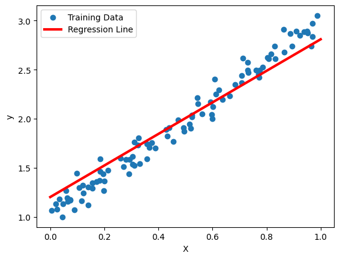

```python
import torch
import torch.nn as nn
import torch.optim as optim
from skorch import NeuralNetRegressor
import numpy as np
import matplotlib.pyplot as plt

# Create a synthetic dataset for regression
np.random.seed(42)
X = np.random.rand(100, 1)
y = 2 * X + 1 + 0.1 * np.random.randn(100, 1)

# Convert X and y to PyTorch tensors
X = torch.tensor(X, dtype=torch.float32)
y = torch.tensor(y, dtype=torch.float32)

# Define a simple neural network model for regression
class SimpleRegressionNN(nn.Module):
    def __init__(self, input_dim):
        super(SimpleRegressionNN, self).__init__()
        self.fc = nn.Linear(input_dim, 1)

    def forward(self, x):
        x = self.fc(x)
        return x

input_dim = 1  # Since we have one feature

# Create a NeuralNetRegressor using skorch
net = NeuralNetRegressor(
    SimpleRegressionNN(input_dim),
    max_epochs=1000,
    lr=0.01,
    optimizer=optim.SGD,
    criterion=nn.MSELoss,
    device='cuda' if torch.cuda.is_available() else 'cpu',
)

# Train the model
net.fit(X, y)

# Generate predictions
X_test = torch.linspace(0, 1, 100).reshape(-1, 1)
y_pred = net.predict(X_test)

# Plot the regression line
plt.scatter(X, y, label='Training Data')
plt.plot(X_test, y_pred, color='red', linewidth=3, label='Regression Line')
plt.xlabel('X')
plt.ylabel('y')
plt.legend()
plt.show()
```

```python
%%shell
jupyter nbconvert --to html /content/Introduction_to_PyTorch_Tensors_Operations_and_Feed_Forward_Neural_Networks.ipynb
```

```
[NbConvertApp] Converting notebook /content/Introduction_to_PyTorch_Tensors_Operations_and_Feed_Forward_Neural_Networks.ipynb to html
[NbConvertApp] Writing 948166 bytes to /content/Introduction_to_PyTorch_Tensors_Operations_and_Feed_Forward_Neural_Networks.html
```